# Compulsory exercise 1: Group 12

## b)

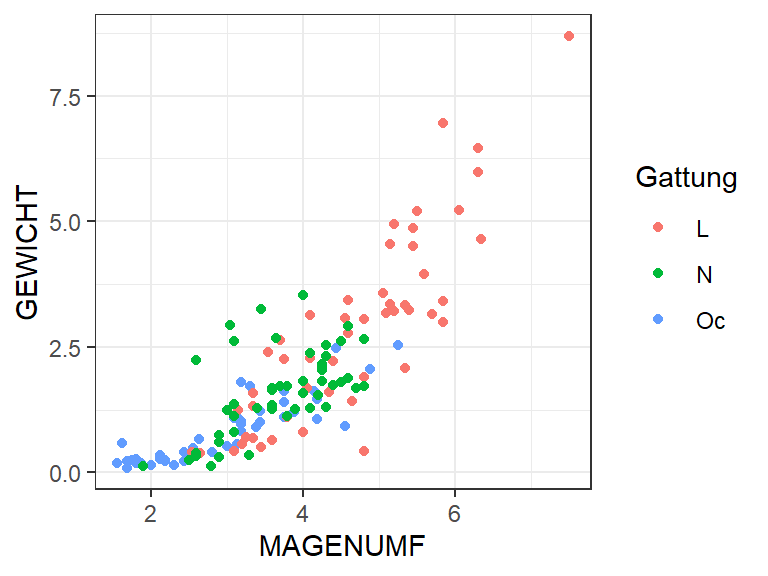

```r
ggplot(d.worm, aes(x = MAGENUMF, y = GEWICHT, colour = Gattung)) + geom_point() +
    theme_bw()
```

The relationship in this scatterplot does not look linear, so we linearize it by transforming the quantitative variables. Here, we take the logarithm of both:

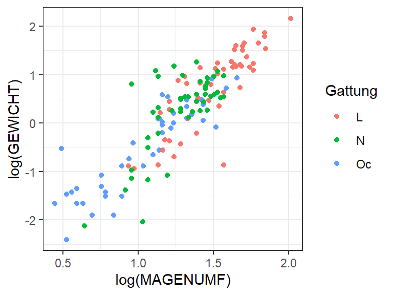

```r
ggplot(d.worm, aes(x = log(MAGENUMF), y = log(GEWICHT), colour = Gattung)) + geom_point() +
    theme_bw()
```

The relationship now looks quite linear, which can be seen more clearly by adding $+ geom\_smooth(method = "lm")$ to the $ggplot()$-function. Especially the species denoted by $L$ and $Oc$ are close to the fitted line, while there is a bigger spread for the species denoted by $N$.

## c)

```r
fit.lm = lm(log(GEWICHT) ~ log(MAGENUMF) + Gattung, data = d.worm)
summary(fit.lm)
```

```
##
## Call:
## lm(formula = log(GEWICHT) ~ log(MAGENUMF) + Gattung, data = d.worm)
##
## Residuals:
##      Min       1Q   Median       3Q      Max
## -1.79642 -0.25996  0.02864  0.25159  1.40557
##
## Coefficients:
##               Estimate Std. Error t value Pr(>|t|)
## (Intercept)   -3.13865    0.24106 -13.020   <2e-16 ***
## log(MAGENUMF)  2.59310    0.15378  16.862   <2e-16 ***
## GattungN       0.07327    0.10252   0.715    0.476
## GattungOc     -0.06149    0.12219  -0.503    0.616
## ---
## Signif. codes:  0 '***' 0.001 '**' 0.01 '*' 0.05 '.' 0.1 ' ' 1
##
## Residual standard error: 0.4832 on 139 degrees of freedom
## Multiple R-squared:  0.7598, Adjusted R-squared:  0.7547
## F-statistic: 146.6 on 3 and 139 DF,  p-value: < 2.2e-16
```

```r
anova(fit.lm)
```

```
## Analysis of Variance Table
##
## Response: log(GEWICHT)
##                Df  Sum Sq Mean Sq  F value Pr(>F)
## log(MAGENUMF)   1 102.264 102.264 438.0809 <2e-16 ***
## Gattung         2   0.394   0.197   0.8441 0.4321
## Residuals     139  32.448   0.233
## ---
## Signif. codes:  0 '***' 0.001 '**' 0.01 '*' 0.05 '.' 0.1 ' ' 1
```

The separate equations of the regression models for the three different species are on the form

$$\text{log(GEWICHT)} = \hat{\beta_0} + \hat{\beta_1} \cdot \text{log(MAGENUMF)} + \hat{\beta_2} x_{i1} + \hat{\beta_3} x_{i2} + \epsilon_i,$$
where $x_{i1}$ and $x_{i2}$ are the dummy variables, given by

$$\begin{equation}
x_{i1} = \Bigg{\{}
\begin{split}
1 &\quad \text{if the ith worm is a Nicodrilus} \\
0 &\quad \text{if the ith worm is not a Nicodrilus}
\end{split}
\end{equation}$$
$$\begin{equation}
x_{i2} = \Bigg{\{}
\begin{split}
1 &\quad \text{if the ith worm is an Octolasion} \\
0 &\quad \text{if the ith worm is not an Octolasion}
\end{split}
\end{equation}$$

## d)

```r
# Test interaction term
fit.lmInter = lm(log(GEWICHT) ~ log(MAGENUMF) * Gattung, data = d.worm)
summary(fit.lmInter)
```

```
##
## Call:
## lm(formula = log(GEWICHT) ~ log(MAGENUMF) * Gattung, data = d.worm)
##
## Residuals:
##     Min      1Q  Median      3Q     Max
## -1.8114 -0.2830  0.0185  0.2457  1.4483
##
## Coefficients:
##                         Estimate Std. Error t value Pr(>|t|)
## (Intercept)             -3.49061    0.42376  -8.237 1.25e-13 ***
## log(MAGENUMF)            2.82702    0.27804  10.168  < 2e-16 ***
## GattungN                 0.19491    0.61075   0.319    0.750
## GattungOc                0.52368    0.48810   1.073    0.285
## log(MAGENUMF):GattungN  -0.05431    0.43824  -0.124    0.902
## log(MAGENUMF):GattungOc -0.45640    0.35462  -1.287    0.200
## ---
## Signif. codes:  0 '***' 0.001 '**' 0.01 '*' 0.05 '.' 0.1 ' ' 1
##
## Residual standard error: 0.4831 on 137 degrees of freedom
## Multiple R-squared:  0.7633, Adjusted R-squared:  0.7547
## F-statistic: 88.36 on 5 and 137 DF,  p-value: < 2.2e-16
```

```r
anova(fit.lmInter)
```

```
## Analysis of Variance Table
##
## Response: log(GEWICHT)
##                        Df  Sum Sq Mean Sq  F value Pr(>F)
## log(MAGENUMF)           1 102.264 102.264 438.1138 <2e-16 ***
## Gattung                 2   0.394   0.197   0.8442 0.4321
## log(MAGENUMF):Gattung   2   0.469   0.235   1.0052 0.3686
## Residuals             137  31.978   0.233
## ---
## Signif. codes:  0 '***' 0.001 '**' 0.01 '*' 0.05 '.' 0.1 ' ' 1
```

## e)

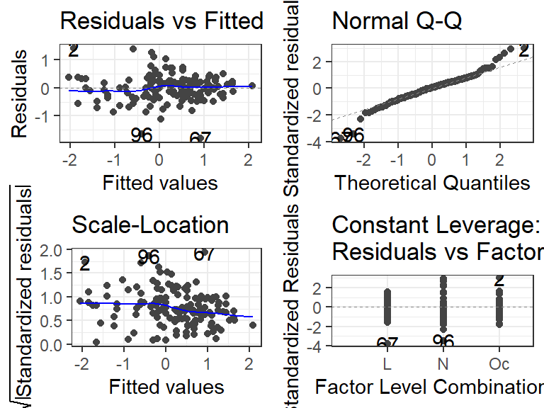

```r
autoplot(fit.lm)  # Residual analysis on our regression model
```

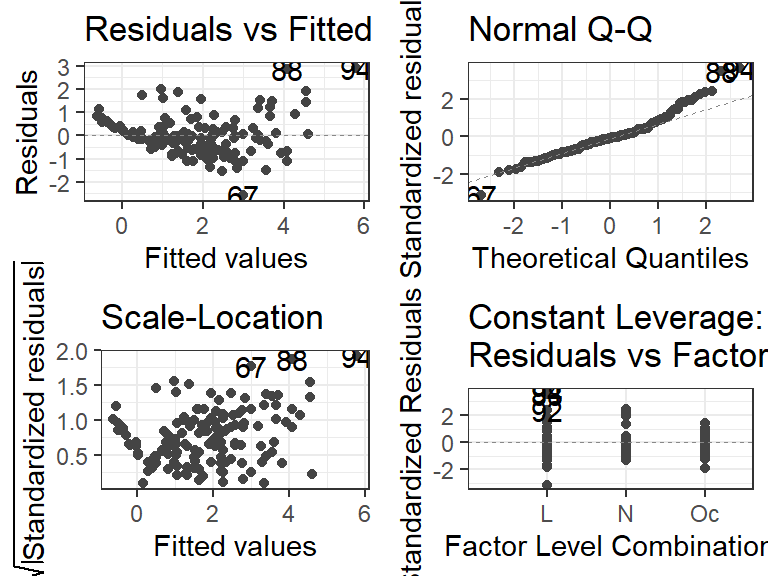

```r
# Compare to the model without transformed variables
fit.lm1 = lm(GEWICHT ~ MAGENUMF + Gattung, data = d.worm)
autoplot(fit.lm1, smooth.colour = NA)
```

## f)

It is important to carry out a residual analysis since we should verify that the underlying assumptions are not violated - if they are so, the model is not valid. In case of violated assumptions, we can for instance remove the outliers and fit the model over again, or we can try other transformations of the predictor value(s).

## g)

FALSE, FALSE, FALSE, TRUE. SJEKK DENNE!!

# Problem 3

In this problem, we will use a dataset from the Wimbledon tennis tournament for Women in 2013. We will predict the result for player 1 (win=1 or loose=0) based on the number of aces won by each player and the number of unforced errors commited by both players. The data set is a subset of a data set from https://archive.ics.uci.edu/ml/datasets/Tennis+Major+Tournament+Match+Statistics, see that page for information of the source of the data.

The files can be read using the following code.

```
##         Player1          Player2       Result           ACE.1
##  S.Lisicki  : 6   K.Flipkens : 5   Min.   :0.0000   Min.   : 0.000
##  M.Bartoli  : 5   N.Li       : 5   1st Qu.:0.0000   1st Qu.: 1.000
##  A.Radwanska: 4   D.Cibulkova: 3   Median :1.0000   Median : 2.000
##  P.Kvitova  : 4   E.Makarova : 3   Mean   :0.5339   Mean   : 2.975
##  R.Vinci    : 4   F.Pennetta : 3   3rd Qu.:1.0000   3rd Qu.: 4.000
##  S.Stephens : 4   K.Kanepi   : 3   Max.   :1.0000   Max.   :14.000
##  (Other)    :91   (Other)    :96
##      UFE.1           ACE.2            UFE.2
##  Min.   : 4.00   Min.   : 0.000   Min.   : 2.00
##  1st Qu.:13.00   1st Qu.: 1.000   1st Qu.:12.00
##  Median :18.00   Median : 2.000   Median :18.00
##  Mean   :20.18   Mean   : 3.271   Mean   :20.47
##  3rd Qu.:25.75   3rd Qu.: 5.000   3rd Qu.:27.00
##  Max.   :54.00   Max.   :15.000   Max.   :55.00
##
```

## a)

Probability to win for player 1 given by a logistic regression model:

$$P(Y_i = 1| {\bf X}={\boldsymbol{x}}_i) = p_i = \frac{e^{\beta_0 + \beta_1x_{i1} + \beta_2 x_{i2} + \beta_3x_{i3} + \beta_4 x_{i4}}}{ 1+ e^{\beta_0 + \beta_1x_{i1} + \beta_2x_{i2}+ \beta_3x_{i3} + \beta_4 x_{i4}}}$$

We first define

$$\beta_0 + \beta_1x_{i1} + \beta_2 x_{i2} + \beta_3x_{i3} + \beta_4 x_{i4} = \beta x$$

Furthermore we know that

$$\begin{aligned}
1-p_i &= 1 - \frac{e^{\beta x}}{1+e^{\beta x}} \\
&= \frac{1 + e^{\beta x} - e^{\beta x}}{1+e^{\beta x}} \\
&= \frac{1}{1+e^{\beta x}}
\end{aligned}$$

Hence we find the linear relation between $p_i$ and the covariates:

$$\begin{aligned}
\text{logit}(p_i) &= \log(\dfrac{p_i}{1-p_i}) \\
&= \log(p_i) - \log({1 - p_i}) \\
&= \log(e^{\beta x}) - \log(1 + e^{\beta x}) - \log(1) + \log({1 + e^{\beta x}}) \\
&= \beta x - 0 \\
&= \beta_0 + \beta_1x_{i1} + \beta_2 x_{i2} + \beta_3x_{i3} + \beta_4 x_{i4}
\end{aligned}$$

## b)

We provide an interpretation of how the coefficients $\beta_i$ affect $p_i$ by looking at the relative change in odds $\frac{p_i}{1-p_i}$ when increasing a covariate $\beta_i$.

$$\begin{aligned}
\frac{\text{odds}(Y_i=1 \mid X_{1} = x_{i1} + 1)}{\text{odds}(Y_i=1 \mid X_j = x_{ij})} &= \frac{e^{\beta_0 + \beta_1 (x_{i1} + 1) + \beta_2 x_{i2} + \beta_3x_{i3} + \beta_4 x_{i4}}}{e^{\beta_0 + \beta_1x_{i1} + \beta_2 x_{i2} + \beta_3x_{i3} + \beta_4 x_{i4}}} \\
&= e^{\beta_11}
\end{aligned}$$

```
##
## Call:
## glm(formula = Result ~ ACE.1 + ACE.2 + UFE.1 + UFE.2, family = "binomial",
##     data = tennis)
##
## Deviance Residuals:
##     Min       1Q   Median       3Q      Max
## -2.0517  -0.8454   0.3725   0.8773   2.0959
##
## Coefficients:
##             Estimate Std. Error z value Pr(>|z|)
## (Intercept) -0.02438    0.59302  -0.041 0.967211
## ACE.1        0.36338    0.10136   3.585 0.000337 ***
## ACE.2       -0.22388    0.07369  -3.038 0.002381 **
## UFE.1       -0.09847    0.02840  -3.467 0.000527 ***
## UFE.2        0.09010    0.02479   3.635 0.000278 ***
## ---
## Signif. codes:  0 '***' 0.001 '**' 0.01 '*' 0.05 '.' 0.1 ' ' 1
##
## (Dispersion parameter for binomial family taken to be 1)
##
##     Null deviance: 163.04  on 117  degrees of freedom
## Residual deviance: 124.96  on 113  degrees of freedom
## AIC: 134.96
##
## Number of Fisher Scoring iterations: 4
```

## c)

We will now use a $0.5$ cutoff rule, meaning we classify an observation $\boldsymbol{x}$ as a win for player 1 if $P(Y = 1 | x) > 0.5$. We find the boundary from

$$\begin{aligned}
P(Y_i = 1| {\bf X}={\boldsymbol{x}}_i) &= p_i \\
&= \frac{e^{\beta x}}{ 1+ e^{\beta x}} = 0.5 \\
&\implies e^{\beta x} = 1 \\
&\implies \beta_0 + \beta_1 x_{1} + \beta_2 x_{2} = 0 \\
&\implies x_2 = -\frac{\beta_1}{\beta_2}x_1 - \frac{\beta_0}{\beta_2}
\end{aligned}$$
Hence we can plot the line $y = ax + b$ with $a = -\frac{\beta_1}{\beta_2}$ and $b = -\frac{\beta_0}{\beta_2}$.

We can now provide a plot with `ACEdiff` as x-axis, `UFEdiff` as y-axis, color the points to indicate win or loss together with our computed boundary. This gives a visual understanding of our classification model.

```r
# make variables for difference
tennis$ACEdiff = tennis$ACE.1 - tennis$ACE.2
tennis$UFEdiff = tennis$UFE.1 - tennis$UFE.2

# divide into test and train set
n = dim(tennis)[1]
n2 = n/2
set.seed(1111)  # to reproduce the same test and train sets each time you run the code
train = sample(c(1:n), replace = F)[1:n2]
tennisTest = tennis[-train, ]
tennisTrain = tennis[train, ]
```

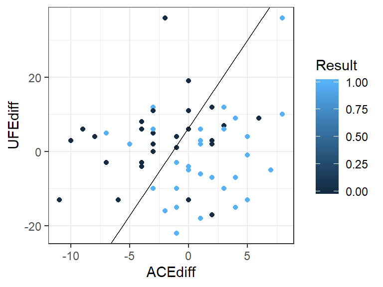

```r
r.tennisLogres = glm(Result ~ ACEdiff + UFEdiff, data = tennisTrain, family = "binomial")

beta = r.tennisLogres$coefficients
a = -beta[1]/beta[3]
b = -beta[2]/beta[3]

plot = ggplot(tennisTrain, aes(x = ACEdiff, y = UFEdiff, color = Result)) + geom_point() +
    geom_abline(slope = b, intercept = a) + theme_bw()

plot
```

Furthermore we can use our model to predict win or loss by player 1 on the test set. As our data set includes the row `Result` we know whether player 1 actually won or not. Hence we find the confusion matrix to measure the accuracy of our model. This also enables us to find the sensitivity and specificity. If $TP$ are true positives, $P$ the sum of predicted and actual positives, $TN$ are true negatives, $N$ the sum of predicted and actual negatives, we have sensitivity given by:

$$\frac{\text{TP}}{\text{P}}$$

And specificity by:

$$\frac{\text{TN}}{\text{N}}$$

[output not shown]

```
## [1] "Sensitivity: 0.838709677419355"
```

```
## [1] "Specificity: 0.571428571428571"
```

## d)

We will now use Linear discriminant analysis (LDA) to classify in the same manner as we did above. Using LDA we assume that our data follow known normal distributions, and we use Bayes theorem to find $P(Y|X)$. Given that we have $K$ classes we find the posterior probability by

$$P(Y=k | {\bf X}={\boldsymbol x}) = \frac{\pi_k f_k({\boldsymbol x})}{\sum_{l=1}^K \pi_l f_l({\boldsymbol x})}$$

$\mu_k$ is the expectation of the covariate $x$ for the different classes. In our case $x$ is a multivariate random vector with two random variables $x = [x_1,x_2]^T$. $x_1$ represents `ACEdiff` and $x_2$ `UFEdiff`. $\mu_1$ is the expecation of $x$ given $Y = 1$, meaning player 1 won the match, $\text{E}[x|Y = 1]$, in the same way $\mu_0$ is the expecation of $x$ in the cases where player 1 lost the match, $\text{E}[x|Y = 0]$. $\mu_k$ is estimated by

$$\hat{\boldsymbol{\mu}}_1 = \frac{1}{n_w}\sum_{i:y_i=1} {\bf X}_i$$

$\Sigma$ is the covariance matrix for $x$, or for `ACEdiff` and `UFEdiff`, our random variables in this case. With a given data set we have the covariance matrix for class $k$:

$$\hat{\boldsymbol{\Sigma}}_k=\frac{1}{n_k-1}\sum_{i:y_i=k} ({\bf X}_i-\hat{\boldsymbol{\mu}}_k ) ({\bf X}_i-\hat{\boldsymbol{\mu}}_k)^T$$

Which we use to find the use the following estimator for the covariance

$$\hat{\boldsymbol{\Sigma}}= \sum_{k=1}^K \frac{n_k - 1}{n - K} \cdot \hat{\boldsymbol{\Sigma}}_k$$

Finally we have the class conditional distributions $f_k(\boldsymbol x) =\text{P}(\boldsymbol X =\boldsymbol x|Y = k)$. These are in the case of LDA and QDA assumed to be normal. This is the distribution of all $x$ that belongs to class $k$. Again, for the tennis problem $f_0(\boldsymbol x)$ gives the distribution for the bivariate variable $\boldsymbol x = [\text{ACEdiff,UFEdiff}]^T$ in the case where player 1 lost, and $f_1(\boldsymbol x)$ in the case where player 1 won.

## e)

**Expression**

We will now derive an expression for $\delta_0({\boldsymbol x}) = \delta_1({\boldsymbol x})$ starting with

$$\begin{aligned}
P(Y=0 | {\bf X}={\boldsymbol x}) &= P(Y=1 | {\bf X}={\boldsymbol x}) \\
\\
\frac{\pi_0 f_0({\boldsymbol x})}{\pi_0 f_0({\boldsymbol x}) + \pi_1 f_1({\boldsymbol x})}
&= \frac{\pi_1 f_1({\boldsymbol x})}{\pi_0 f_0({\boldsymbol x}) + \pi_1 f_1({\boldsymbol x})} \\
\\
\pi_0 f_0({\boldsymbol x})
&= \pi_1 f_1({\boldsymbol x})
\end{aligned}$$

Where $f_k(\boldsymbol{x})$ is defined as

$$f_k({\boldsymbol x}) = \frac{1}{(2 \pi)^{p/2}|\boldsymbol{\Sigma}|^{1/2}}e^{-\dfrac{1}{2}({\boldsymbol x}-\boldsymbol{\mu_k})^T \boldsymbol{\Sigma}^{-1}({\boldsymbol x}-\boldsymbol{\mu_k})}$$

We see that the term outside the exponent cancels because of the assumption that $\Sigma_0 = \Sigma_1 = \Sigma$, hence we take $\log$ on both sides to get:

$$\begin{aligned}
-\dfrac{1}{2}({\boldsymbol x}-\boldsymbol{\mu_0})^T \boldsymbol{\Sigma}^{-1}({\boldsymbol x}-\boldsymbol{\mu_0}) + \log\pi_0
&= -\dfrac{1}{2}({\boldsymbol x}-\boldsymbol{\mu_1})^T \boldsymbol{\Sigma}^{-1}({\boldsymbol x}-\boldsymbol{\mu_1}) + \log\pi_1 \\
\end{aligned}$$

Finally terms independent of $k$ cancels, like $x^T\Sigma^{-1}x$. Furthermore, by the symmetry of $\Sigma$ and the fact that $b^T = b$ when $b \in \mathbb{R}$ we get

$$\begin{aligned}
{\boldsymbol x}^T \boldsymbol{\Sigma}^{-1}\boldsymbol{\mu}_0 - \frac{1}{2}\boldsymbol{\mu}_0^T \boldsymbol{\Sigma}^{-1}\boldsymbol{\mu}_0 + \log \pi_0
&=
{\boldsymbol x}^T \boldsymbol{\Sigma}^{-1}\boldsymbol{\mu}_1 - \frac{1}{2}\boldsymbol{\mu}_1^T \boldsymbol{\Sigma}^{-1}\boldsymbol{\mu}_1 + \log \pi_1 \\
\delta_0({\boldsymbol x}) &= \delta_1({\boldsymbol x})
\end{aligned}$$

**Function for class boundary**

We will now derive the class boundary by using the expression we have derived above. As we know that $$

We can use $\delta_0({\boldsymbol x}) = \delta_1({\boldsymbol x})$ to find

$${\boldsymbol x}^T\boldsymbol{\Sigma}^{-1}(\boldsymbol\mu_0 -\boldsymbol\mu_1)-\frac{1}{2}\boldsymbol\mu_0^T \boldsymbol{\Sigma}^{-1}\boldsymbol\mu_0 +\frac{1}{2}\boldsymbol\mu_1^T \boldsymbol{\Sigma}^{-1}\boldsymbol\mu_1 +\log\dfrac{ \pi_0}{ \pi_1}=0$$

By defining

$$[\alpha_1,\alpha_2] = \boldsymbol{\Sigma}^{-1}(\boldsymbol\mu_0 -\boldsymbol\mu_1)$$

we get

$$[x_1,x_2]^T[\alpha_1,\alpha_2] = x_1\alpha_1 + x_2\alpha_2$$

and finally we have

$$x_2
= x_1\frac{\alpha_1}{\alpha_2} + \frac{1}{2\alpha_2}
(\boldsymbol\mu_0^T \boldsymbol{\Sigma}^{-1}\boldsymbol\mu_0
-\boldsymbol\mu_1^T \boldsymbol{\Sigma}^{-1}\boldsymbol\mu_1 -2\log\dfrac{ \pi_0}{ \pi_1})$$

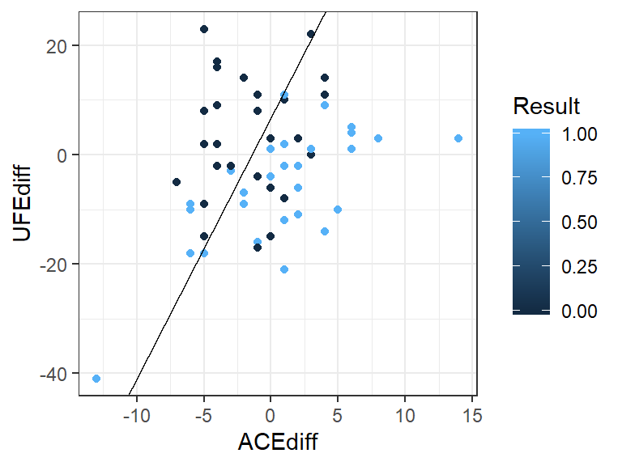

```r
n = nrow(tennisTrain)

r1 = tennisTrain[tennisTrain$Result == 1, ]
r1 = select(r1, ACEdiff, UFEdiff)
mu1 = colMeans(r1)
cov1 = cov(r1)
pi1 = nrow(r1)/n

r0 = tennisTrain[tennisTrain$Result == 0, ]
r0 = select(r0, ACEdiff, UFEdiff)
mu0 = colMeans(r0)
cov0 = cov(r0)
pi0 = nrow(r0)/n

covEst = (1/(n - 2)) * ((nrow(r0) - 1) * cov0 + ((nrow(r1) - 1) * cov1))
covInv = solve(covEst)

alpha = covInv %*% (mu0 - mu1)
a = -alpha[1]/alpha[2]
b = (1/(2 * alpha[2])) * (t(mu0) %*% covInv %*% mu0 - t(mu1) %*% covInv %*% mu1 -
    2 * log(pi0/pi1))

plot = ggplot(tennisTest, aes(x = ACEdiff, y = UFEdiff, color = Result)) + geom_point() +
    geom_abline(slope = a, intercept = b) + theme_bw()

plot
```

## f)

```r
r.tennisLDA = lda(Result ~ ACEdiff + UFEdiff, data = tennisTrain)
tennisLDAPred = predict(r.tennisLDA, tennisTest)$class

tennisLDACM = table(real = tennisTest$Result, predicted = tennisLDAPred)
tennisLDACM
```

```
##     predicted
## real  0  1
##    0 16 12
##    1  5 26
```

```r
sensLDA = tennisLDACM[2, 2]/sum(tennisLDACM[2, ])
print(paste0("Sensitivity: ", sensLDA))
```

```
## [1] "Sensitivity: 0.838709677419355"
```

```r
specLDA = tennisLDACM[1, 1]/sum(tennisLDACM[1, ])
print(paste0("Specificity: ", specLDA))
```

```
## [1] "Specificity: 0.571428571428571"
```

## g)

When we derived the decision boundary for LDA we assumed that each class have equal covariance matrices. For QDA we do not assume this and hence the quadratic terms of $x$ do not cancel and we obviously get a decision boundary that is quadratic.

```r
r.tennisQDA = qda(Result ~ ACEdiff + UFEdiff, data = tennisTrain)
tennisQDAPred = predict(r.tennisQDA, tennisTest)$class

tennisQDACM = table(real = tennisTest$Result, predicted = tennisQDAPred)
tennisQDACM
```

```
##     predicted
## real  0  1
##    0 15 13
##    1  5 26
```

```r
sensQDA = tennisQDACM[2, 2]/sum(tennisQDACM[2, ])
print(paste0("Sensitivity: ", sensQDA))
```

```
## [1] "Sensitivity: 0.838709677419355"
```

```r
specQDA = tennisQDACM[1, 1]/sum(tennisQDACM[1, ])
print(paste0("Specificity: ", specQDA))
```

```
## [1] "Specificity: 0.535714285714286"
```

## h)

For one run with $\text{seed} = 1234$ we get the following sensitivity and specificity for the different methods.

|  | Sens | Spec | SUM |
| --- | --- | --- | --- |
| glm | 0.80 | 0.76 | 1.56 |
| LDA | 0.83 | 0.69 | 1.52 |
| QDA | 0.80 | 0.69 | 1.49 |

However, in order to get a result that is not dependent on only one sample, we can run the classifiers $n$ times with new random test / training samples each time, and then taking the average of the sensitivity and specificity for each method. Here is the result for running the function below for $n=1000$:

[output not shown]

Hence we would prefer to use glm or LDA. However, as LDA has a slightly better probability of classifying the matches where player 1 won, it could be preferable if we care more about predicting wins than losses.

```r
tennis_classification = function(runs) {
    res = matrix(0L, nrow = 3, ncol = 2)

    for (i in 1:runs) {

        # make variables for difference
        tennis$ACEdiff = tennis$ACE.1 - tennis$ACE.2
        tennis$UFEdiff = tennis$UFE.1 - tennis$UFE.2

        # divide into test and train set
        n = dim(tennis)[1]
        n2 = n/2
        train = sample(c(1:n), replace = F)[1:n2]
        tennisTest = tennis[-train, ]
        tennisTrain = tennis[train, ]

        # Logistical regression
        r.tennisLogres = glm(Result ~ ACEdiff + UFEdiff, data = tennisTrain, family = "binomial")
        tennisLogresPred = predict(r.tennisLogres, newdata = tennisTest, type = "response")
        tennisLogresResult = ifelse(tennisLogresPred < 0.5, 0, 1)
        tennisLogresCM = table(real = tennisTest$Result, pred = tennisLogresResult)
        res[1, 1] = res[1, 1] + tennisLogresCM[2, 2]/sum(tennisLogresCM[2, ])
        res[1, 2] = res[1, 2] + tennisLogresCM[1, 1]/sum(tennisLogresCM[1, ])

        # LDA
        r.tennisLDA = lda(Result ~ ACEdiff + UFEdiff, data = tennisTrain)
        tennisLDAPred = predict(r.tennisLDA, tennisTest)$class
        tennisLDACM = table(real = tennisTest$Result, predicted = tennisLDAPred)
        res[2, 1] = res[2, 1] + tennisLDACM[2, 2]/sum(tennisLDACM[2, ])
        res[2, 2] = res[2, 2] + tennisLDACM[1, 1]/sum(tennisLDACM[1, ])

        # QDA
        r.tennisQDA = qda(Result ~ ACEdiff + UFEdiff, data = tennisTrain)
        tennisQDAPred = predict(r.tennisQDA, tennisTest)$class
        tennisQDACM = table(real = tennisTest$Result, predicted = tennisQDAPred)
        res[3, 1] = res[3, 1] + tennisQDACM[2, 2]/sum(tennisQDACM[2, ])
        res[3, 2] = res[3, 2] + tennisQDACM[1, 1]/sum(tennisQDACM[1, ])
    }

    return(res/runs)
}

res = tennis_classification(1000)
res
```

```
##           [,1]      [,2]
## [1,] 0.7801013 0.6775830
## [2,] 0.7871556 0.6713058
## [3,] 0.7818750 0.6456521
```

# Problem 4

## a)

10 fold cross validation on the KNN regression would be performed by partitioning the training data $D$ into 10 equal size sets $D_i$. For each of the 10 sets, leave the set out form the data and calculate a test error using the set as test data. Then average the test errors for all the 10 sets. More precisely we would use test MSE as error measure. let $\mathcal{N_i(x)}$ be the $K$ closest point in $D \setminus D_i$ to $x$. The test MSE is calculated as
$$\mathrm{MSE}_{i}=\frac{1}{|D_i|}\sum^{|D_i|}_{j=1}{(y_j-\frac{1}{K}\sum_{l\in \mathcal{N_i(x_j)}}{y_l} )^2 },$$
where $y_j,y_j \in D_i$ and $y_l$ is the observed response at $l$. The validation error is then calculated as

$$\mathrm{CV}_{10}=\frac{1}{10}\sum^{10}_{i=10}{\mathrm{MSE}_{i}}.$$

## b)

TRUE, TRUE, TRUE, FALSE